# Gold Mining

Fantasy Football Analytics

15 November, 2014

The graph below summarizes the projections from a variety of sources. This week’s summary includes projections from: Fantasy Football Sharks, CBS’s Jamey Eisenberg, CBS’s Dave Richard, Fantasy Football Today, ESPN, Picking Pros, Yahoo Sports and Fox Sports.

## Standard Scoring Leagues

### Week 11 Wide Receivers

From this graph be sure to notice:

- Alshon Jeffery, Golden Tate, Pierre Garcon, Eddie Royal and Wes Welker are the five players with the **largest upside** (as measured from their pseudo-medians). For these players, some projections are placing much higher valuations than others. If you are projected to lose this week by quite a few points and are looking for a risky play that may tip the balance in your favor, these are players to consider.
- Pierre Garcon, Reggie Wayne, Marques Colston, Doug Baldwin and Rueben Randle are the players with the **smallest downside**, which suggests that while their median projection might not be great, there is less uncertainty concerning how poorly they may perform. So, if you are projected to win by a lot and want to reduce your downside risk, these players may deserve extra attention.
- On the other hand, Emmanuel Sanders, T.Y. Hilton, Alshon Jeffery, Golden Tate and Brandon Marshall are the five players with the **largest downside** this week. If you are planning on starting them, it may be prudent to investigate why some projections have such low expectations for these players.

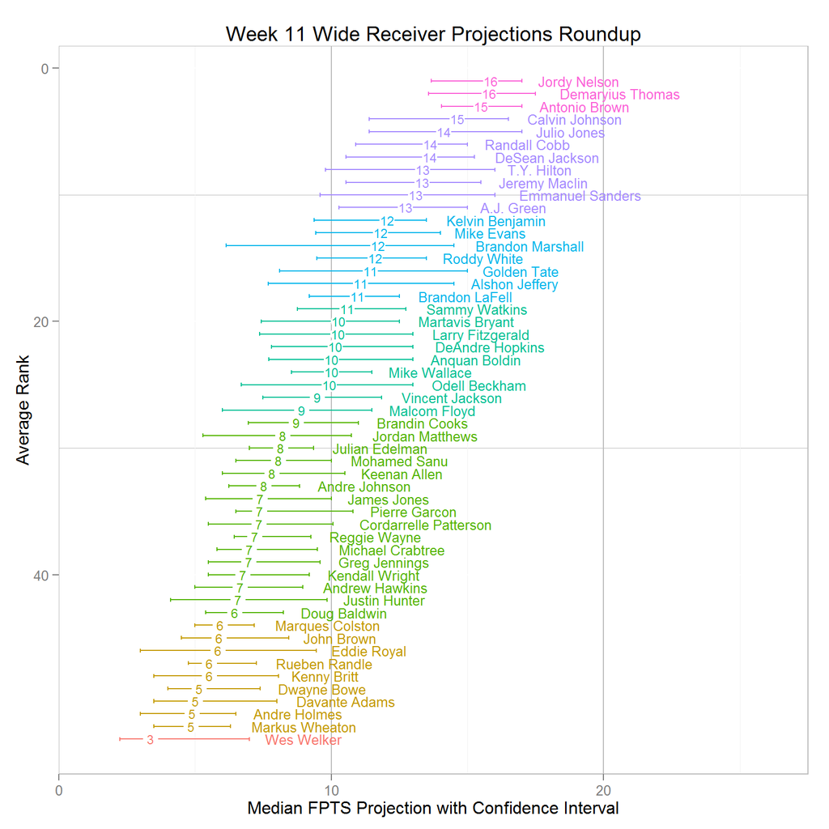

## PPR Leagues

### Week 11 Wide Receivers

From this graph be sure to notice:

- Golden Tate, Alshon Jeffery, Odell Beckham, Pierre Garcon and Wes Welker are the five players with the **largest upside** (as measured from their pseudo-medians). For these players, some projections are placing much higher valuations than others. If you are projected to lose this week by quite a few points and are looking for a risky play that may tip the balance in your favor, these are players to consider.
- Mike Wallace, Pierre Garcon, Reggie Wayne, Michael Crabtree and Doug Baldwin are the players with the **smallest downside**, which suggests that while their median projection might not be great, there is less uncertainty concerning how poorly they may perform. So, if you are likely to win by a lot and want to reduce your downside risk, these players may deserve extra attention.
- On the other hand, Emmanuel Sanders, T.Y. Hilton, A.J. Green, Golden Tate and Brandon Marshall are the five players with the **largest downside** this week. If you are planning on starting them, it may be prudent to investigate why some projections have such low expectations for these players.

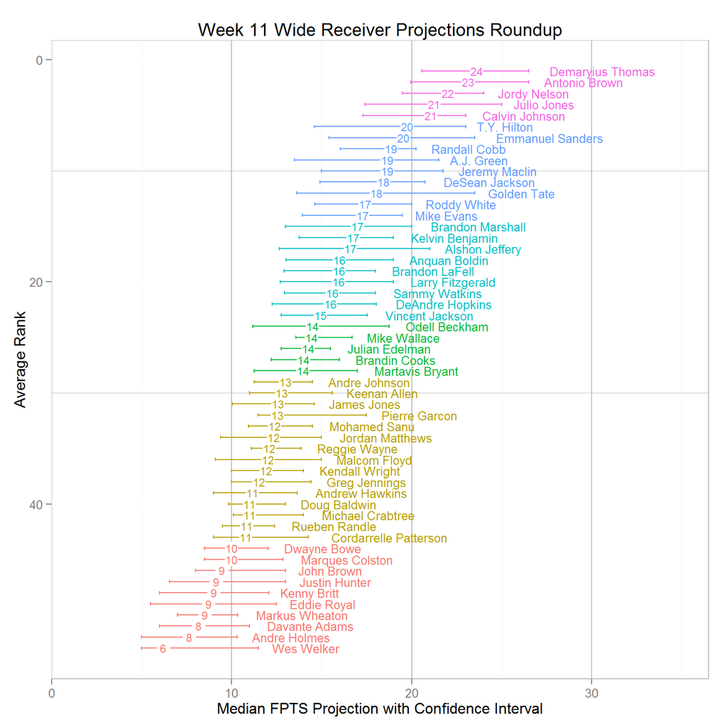